# Risk Factor Analysis

## Outcome Variable

**Outcome Variable:** y_rate_haz

## Predictor Variables

**Intervention Variable:** pers_wast

**Adjustment Set:**

unadjusted

## Stratifying Variables

The analysis was stratified on these variable(s):

- agecat
- studyid
- country

## Data Summary

| agecat | studyid | country | pers_wast | n_cell | n |
| --- | --- | --- | --- | --- | --- |
| 0-3 months | ki0047075b-MAL-ED | BANGLADESH | 0 | 237 | 244 |
| 0-3 months | ki0047075b-MAL-ED | BANGLADESH | 1 | 7 | 244 |
| 0-3 months | ki1017093b-PROVIDE | BANGLADESH | 0 | 619 | 634 |
| 0-3 months | ki1017093b-PROVIDE | BANGLADESH | 1 | 15 | 634 |
| 0-3 months | ki1114097-CMIN | BANGLADESH | 0 | 41 | 43 |
| 0-3 months | ki1114097-CMIN | BANGLADESH | 1 | 2 | 43 |
| 0-3 months | ki0047075b-MAL-ED | BRAZIL | 0 | 180 | 180 |
| 0-3 months | ki1101329-Keneba | GAMBIA | 0 | 1246 | 1276 |
| 0-3 months | ki1101329-Keneba | GAMBIA | 1 | 30 | 1276 |
| 0-3 months | ki0047075b-MAL-ED | INDIA | 0 | 187 | 201 |
| 0-3 months | ki0047075b-MAL-ED | INDIA | 1 | 14 | 201 |
| 0-3 months | ki1000108-CMC-V-BCS-2002 | INDIA | 0 | 78 | 87 |
| 0-3 months | ki1000108-CMC-V-BCS-2002 | INDIA | 1 | 9 | 87 |
| 0-3 months | ki1000108-IRC | INDIA | 0 | 310 | 377 |
| 0-3 months | ki1000108-IRC | INDIA | 1 | 67 | 377 |
| 0-3 months | ki0047075b-MAL-ED | NEPAL | 0 | 172 | 175 |
| 0-3 months | ki0047075b-MAL-ED | NEPAL | 1 | 3 | 175 |
| 0-3 months | ki1000109-EE | PAKISTAN | 0 | 277 | 297 |
| 0-3 months | ki1000109-EE | PAKISTAN | 1 | 20 | 297 |
| 0-3 months | ki1000109-ResPak | PAKISTAN | 0 | 69 | 78 |
| 0-3 months | ki1000109-ResPak | PAKISTAN | 1 | 9 | 78 |
| 0-3 months | ki0047075b-MAL-ED | PERU | 0 | 271 | 271 |
| 0-3 months | ki1114097-CMIN | PERU | 0 | 89 | 93 |
| 0-3 months | ki1114097-CMIN | PERU | 1 | 4 | 93 |
| 0-3 months | ki1114097-CONTENT | PERU | 0 | 29 | 29 |
| 0-3 months | ki0047075b-MAL-ED | SOUTH AFRICA | 0 | 227 | 229 |
| 0-3 months | ki0047075b-MAL-ED | SOUTH AFRICA | 1 | 2 | 229 |
| 0-3 months | ki0047075b-MAL-ED | TANZANIA, UNITED REPUBLIC OF | 0 | 229 | 229 |
| 3-6 months | ki0047075b-MAL-ED | BANGLADESH | 0 | 226 | 231 |
| 3-6 months | ki0047075b-MAL-ED | BANGLADESH | 1 | 5 | 231 |

[output cut: 94 more lines]

The following strata were considered:

- agecat: 0-3 months, studyid: ki0047075b-MAL-ED, country: BANGLADESH
- agecat: 0-3 months, studyid: ki0047075b-MAL-ED, country: BRAZIL
- agecat: 0-3 months, studyid: ki0047075b-MAL-ED, country: INDIA
- agecat: 0-3 months, studyid: ki0047075b-MAL-ED, country: NEPAL
- agecat: 0-3 months, studyid: ki0047075b-MAL-ED, country: PERU
- agecat: 0-3 months, studyid: ki0047075b-MAL-ED, country: SOUTH AFRICA
- agecat: 0-3 months, studyid: ki0047075b-MAL-ED, country: TANZANIA, UNITED REPUBLIC OF
- agecat: 0-3 months, studyid: ki1000108-CMC-V-BCS-2002, country: INDIA
- agecat: 0-3 months, studyid: ki1000108-IRC, country: INDIA
- agecat: 0-3 months, studyid: ki1000109-EE, country: PAKISTAN
- agecat: 0-3 months, studyid: ki1000109-ResPak, country: PAKISTAN
- agecat: 0-3 months, studyid: ki1017093b-PROVIDE, country: BANGLADESH
- agecat: 0-3 months, studyid: ki1101329-Keneba, country: GAMBIA
- agecat: 0-3 months, studyid: ki1114097-CMIN, country: BANGLADESH
- agecat: 0-3 months, studyid: ki1114097-CMIN, country: PERU
- agecat: 0-3 months, studyid: ki1114097-CONTENT, country: PERU
- agecat: 12-24 months, studyid: ki0047075b-MAL-ED, country: BANGLADESH
- agecat: 12-24 months, studyid: ki0047075b-MAL-ED, country: BRAZIL
- agecat: 12-24 months, studyid: ki0047075b-MAL-ED, country: INDIA
- agecat: 12-24 months, studyid: ki0047075b-MAL-ED, country: NEPAL
- agecat: 12-24 months, studyid: ki0047075b-MAL-ED, country: PERU
- agecat: 12-24 months, studyid: ki0047075b-MAL-ED, country: SOUTH AFRICA
- agecat: 12-24 months, studyid: ki0047075b-MAL-ED, country: TANZANIA, UNITED REPUBLIC OF
- agecat: 12-24 months, studyid: ki1000108-CMC-V-BCS-2002, country: INDIA
- agecat: 12-24 months, studyid: ki1000108-IRC, country: INDIA
- agecat: 12-24 months, studyid: ki1017093b-PROVIDE, country: BANGLADESH
- agecat: 12-24 months, studyid: ki1066203-TanzaniaChild2, country: TANZANIA, UNITED REPUBLIC OF
- agecat: 12-24 months, studyid: ki1101329-Keneba, country: GAMBIA
- agecat: 12-24 months, studyid: ki1113344-GMS-Nepal, country: NEPAL
- agecat: 12-24 months, studyid: ki1114097-CMIN, country: BANGLADESH
- agecat: 12-24 months, studyid: ki1114097-CMIN, country: PERU
- agecat: 12-24 months, studyid: ki1114097-CONTENT, country: PERU
- agecat: 3-6 months, studyid: ki0047075b-MAL-ED, country: BANGLADESH
- agecat: 3-6 months, studyid: ki0047075b-MAL-ED, country: BRAZIL
- agecat: 3-6 months, studyid: ki0047075b-MAL-ED, country: INDIA
- agecat: 3-6 months, studyid: ki0047075b-MAL-ED, country: NEPAL
- agecat: 3-6 months, studyid: ki0047075b-MAL-ED, country: PERU
- agecat: 3-6 months, studyid: ki0047075b-MAL-ED, country: SOUTH AFRICA
- agecat: 3-6 months, studyid: ki0047075b-MAL-ED, country: TANZANIA, UNITED REPUBLIC OF
- agecat: 3-6 months, studyid: ki1000108-CMC-V-BCS-2002, country: INDIA
- agecat: 3-6 months, studyid: ki1000108-IRC, country: INDIA
- agecat: 3-6 months, studyid: ki1000109-EE, country: PAKISTAN
- agecat: 3-6 months, studyid: ki1000109-ResPak, country: PAKISTAN
- agecat: 3-6 months, studyid: ki1017093b-PROVIDE, country: BANGLADESH
- agecat: 3-6 months, studyid: ki1066203-TanzaniaChild2, country: TANZANIA, UNITED REPUBLIC OF
- agecat: 3-6 months, studyid: ki1101329-Keneba, country: GAMBIA
- agecat: 3-6 months, studyid: ki1113344-GMS-Nepal, country: NEPAL
- agecat: 3-6 months, studyid: ki1114097-CMIN, country: BANGLADESH
- agecat: 3-6 months, studyid: ki1114097-CMIN, country: PERU
- agecat: 3-6 months, studyid: ki1114097-CONTENT, country: PERU
- agecat: 6-12 months, studyid: ki0047075b-MAL-ED, country: BANGLADESH
- agecat: 6-12 months, studyid: ki0047075b-MAL-ED, country: BRAZIL
- agecat: 6-12 months, studyid: ki0047075b-MAL-ED, country: INDIA
- agecat: 6-12 months, studyid: ki0047075b-MAL-ED, country: NEPAL
- agecat: 6-12 months, studyid: ki0047075b-MAL-ED, country: PERU
- agecat: 6-12 months, studyid: ki0047075b-MAL-ED, country: SOUTH AFRICA
- agecat: 6-12 months, studyid: ki0047075b-MAL-ED, country: TANZANIA, UNITED REPUBLIC OF
- agecat: 6-12 months, studyid: ki1000108-CMC-V-BCS-2002, country: INDIA
- agecat: 6-12 months, studyid: ki1000108-IRC, country: INDIA
- agecat: 6-12 months, studyid: ki1000109-EE, country: PAKISTAN
- agecat: 6-12 months, studyid: ki1000109-ResPak, country: PAKISTAN
- agecat: 6-12 months, studyid: ki1017093b-PROVIDE, country: BANGLADESH
- agecat: 6-12 months, studyid: ki1066203-TanzaniaChild2, country: TANZANIA, UNITED REPUBLIC OF
- agecat: 6-12 months, studyid: ki1101329-Keneba, country: GAMBIA
- agecat: 6-12 months, studyid: ki1112895-Guatemala BSC, country: GUATEMALA
- agecat: 6-12 months, studyid: ki1113344-GMS-Nepal, country: NEPAL
- agecat: 6-12 months, studyid: ki1114097-CMIN, country: BANGLADESH
- agecat: 6-12 months, studyid: ki1114097-CMIN, country: PERU
- agecat: 6-12 months, studyid: ki1114097-CONTENT, country: PERU

### Dropped Strata

Some strata were dropped due to rare outcomes:

- agecat: 0-3 months, studyid: ki1114097-CMIN, country: BANGLADESH
- agecat: 0-3 months, studyid: ki0047075b-MAL-ED, country: NEPAL
- agecat: 0-3 months, studyid: ki1114097-CMIN, country: PERU
- agecat: 0-3 months, studyid: ki0047075b-MAL-ED, country: SOUTH AFRICA
- agecat: 3-6 months, studyid: ki0047075b-MAL-ED, country: BRAZIL
- agecat: 3-6 months, studyid: ki0047075b-MAL-ED, country: NEPAL
- agecat: 3-6 months, studyid: ki0047075b-MAL-ED, country: SOUTH AFRICA
- agecat: 6-12 months, studyid: ki0047075b-MAL-ED, country: BRAZIL
- agecat: 6-12 months, studyid: ki1112895-Guatemala BSC, country: GUATEMALA
- agecat: 6-12 months, studyid: ki0047075b-MAL-ED, country: NEPAL
- agecat: 6-12 months, studyid: ki1000109-EE, country: PAKISTAN
- agecat: 6-12 months, studyid: ki0047075b-MAL-ED, country: SOUTH AFRICA
- agecat: 12-24 months, studyid: ki1114097-CMIN, country: BANGLADESH
- agecat: 12-24 months, studyid: ki0047075b-MAL-ED, country: BRAZIL
- agecat: 12-24 months, studyid: ki0047075b-MAL-ED, country: NEPAL
- agecat: 12-24 months, studyid: ki1114097-CMIN, country: PERU
- agecat: 12-24 months, studyid: ki0047075b-MAL-ED, country: SOUTH AFRICA
- agecat: 12-24 months, studyid: ki1066203-TanzaniaChild2, country: TANZANIA, UNITED REPUBLIC OF

## Methods Detail

We’re interested in the causal parameters $E[Y_a]$ for all values of $a \in \mathcal{A}$. These parameters represent the mean outcome if, possibly contrary to fact, we intervened to set all units to have $A=a$. Under the randomization and positivity assumptions, these are identified by the statistical parameters $\psi_a=E_W[E_{Y|A,W}(Y|A=a,W)]$. In addition, we’re interested in the mean of $Y$, $E[Y]$ under no intervention (the observed mean). We will estimate these parameters by using SuperLearner to fit the relevant likelihood factors – $E_{Y|A,W}(Y|A=a,W)$ and $p(A=a|W)$, and then updating our likelihood fit using a joint TMLE.

For unadjusted analyses ($W=\{\}$), initial likelihoods were estimated using Lrnr_glm to estimate the simple $E(Y|A)$ and Lrnr_mean to estimate $p(A)$. For adjusted analyses, a small library containing Lrnr_glmnet, Lrnr_xgboost, and Lrnr_mean was used.

Having estimated these parameters, we will then use the delta method to estimate relative risks and attributable risks relative to a prespecified baseline level of $A$.

[output not shown]

[output cut: 3017 more lines]

[output not shown]

# Results Detail

## Results Plots

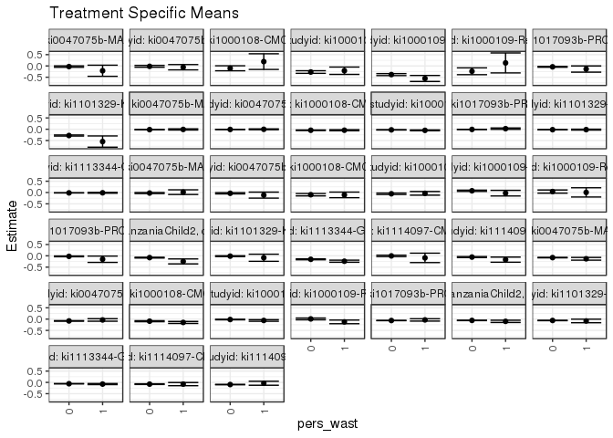

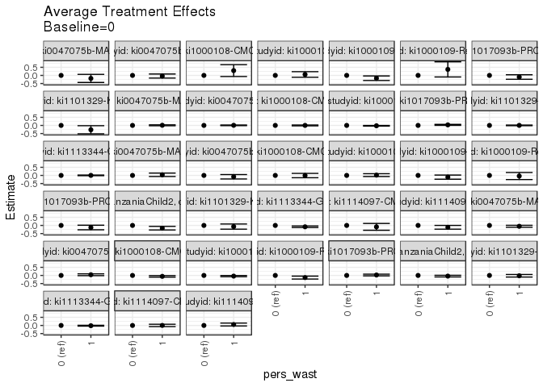

## Results Table

### Parameter: TSM

| agecat | studyid | country | intervention_level | baseline_level | estimate | ci_lower | ci_upper |
| --- | --- | --- | --- | --- | --- | --- | --- |
| 0-3 months | ki0047075b-MAL-ED | BANGLADESH | 0 | NA | -0.0286106 | -0.0605700 | 0.0033487 |
| 0-3 months | ki0047075b-MAL-ED | BANGLADESH | 1 | NA | -0.2132003 | -0.4597993 | 0.0333988 |
| 0-3 months | ki0047075b-MAL-ED | INDIA | 0 | NA | -0.0177525 | -0.0589215 | 0.0234166 |
| 0-3 months | ki0047075b-MAL-ED | INDIA | 1 | NA | -0.0569083 | -0.1747131 | 0.0608965 |
| 0-3 months | ki1000108-CMC-V-BCS-2002 | INDIA | 0 | NA | -0.1039000 | -0.2146985 | 0.0068985 |
| 0-3 months | ki1000108-CMC-V-BCS-2002 | INDIA | 1 | NA | 0.1919466 | -0.1556558 | 0.5395490 |
| 0-3 months | ki1000108-IRC | INDIA | 0 | NA | -0.2696984 | -0.3280012 | -0.2113956 |
| 0-3 months | ki1000108-IRC | INDIA | 1 | NA | -0.2122930 | -0.3741696 | -0.0504164 |
| 0-3 months | ki1000109-EE | PAKISTAN | 0 | NA | -0.3822390 | -0.4266015 | -0.3378765 |
| 0-3 months | ki1000109-EE | PAKISTAN | 1 | NA | -0.5546870 | -0.6870533 | -0.4223206 |
| 0-3 months | ki1000109-ResPak | PAKISTAN | 0 | NA | -0.2362023 | -0.3866052 | -0.0857993 |
| 0-3 months | ki1000109-ResPak | PAKISTAN | 1 | NA | 0.1339200 | -0.3078040 | 0.5756439 |
| 0-3 months | ki1017093b-PROVIDE | BANGLADESH | 0 | NA | -0.0389829 | -0.0572345 | -0.0207313 |
| 0-3 months | ki1017093b-PROVIDE | BANGLADESH | 1 | NA | -0.1375227 | -0.2750453 | -0.0000001 |
| 0-3 months | ki1101329-Keneba | GAMBIA | 0 | NA | -0.2787644 | -0.3025834 | -0.2549454 |
| 0-3 months | ki1101329-Keneba | GAMBIA | 1 | NA | -0.5462735 | -0.7958082 | -0.2967388 |
| 3-6 months | ki0047075b-MAL-ED | BANGLADESH | 0 | NA | -0.0233773 | -0.0468832 | 0.0001285 |
| 3-6 months | ki0047075b-MAL-ED | BANGLADESH | 1 | NA | 0.0161823 | -0.0869137 | 0.1192783 |
| 3-6 months | ki0047075b-MAL-ED | INDIA | 0 | NA | -0.0337625 | -0.0622693 | -0.0052557 |
| 3-6 months | ki0047075b-MAL-ED | INDIA | 1 | NA | -0.1147088 | -0.2473934 | 0.0179758 |
| 3-6 months | ki1000108-CMC-V-BCS-2002 | INDIA | 0 | NA | -0.0969043 | -0.1485086 | -0.0452999 |
| 3-6 months | ki1000108-CMC-V-BCS-2002 | INDIA | 1 | NA | -0.1042809 | -0.2280103 | 0.0194484 |
| 3-6 months | ki1000108-IRC | INDIA | 0 | NA | -0.0552177 | -0.0874681 | -0.0229673 |
| 3-6 months | ki1000108-IRC | INDIA | 1 | NA | -0.0358004 | -0.1164384 | 0.0448376 |
| 3-6 months | ki1000109-EE | PAKISTAN | 0 | NA | 0.0771192 | 0.0483910 | 0.1058474 |
| 3-6 months | ki1000109-EE | PAKISTAN | 1 | NA | -0.0282461 | -0.1524225 | 0.0959304 |
| 3-6 months | ki1000109-ResPak | PAKISTAN | 0 | NA | 0.0423529 | -0.0277425 | 0.1124484 |
| 3-6 months | ki1000109-ResPak | PAKISTAN | 1 | NA | 0.0051858 | -0.1993127 | 0.2096842 |
| 3-6 months | ki1017093b-PROVIDE | BANGLADESH | 0 | NA | -0.0241357 | -0.0405522 | -0.0077192 |
| 3-6 months | ki1017093b-PROVIDE | BANGLADESH | 1 | NA | -0.1515279 | -0.2910674 | -0.0119884 |
| 3-6 months | ki1066203-TanzaniaChild2 | TANZANIA, UNITED REPUBLIC OF | 0 | NA | -0.0798094 | -0.0965889 | -0.0630298 |
| 3-6 months | ki1066203-TanzaniaChild2 | TANZANIA, UNITED REPUBLIC OF | 1 | NA | -0.2478728 | -0.3579543 | -0.1377913 |
| 3-6 months | ki1101329-Keneba | GAMBIA | 0 | NA | -0.0148690 | -0.0332905 | 0.0035525 |
| 3-6 months | ki1101329-Keneba | GAMBIA | 1 | NA | -0.0858389 | -0.2432772 | 0.0715994 |
| 3-6 months | ki1113344-GMS-Nepal | NEPAL | 0 | NA | -0.1553132 | -0.1752412 | -0.1353851 |
| 3-6 months | ki1113344-GMS-Nepal | NEPAL | 1 | NA | -0.2391789 | -0.2851285 | -0.1932293 |
| 3-6 months | ki1114097-CMIN | BANGLADESH | 0 | NA | -0.0038663 | -0.0360392 | 0.0283067 |
| 3-6 months | ki1114097-CMIN | BANGLADESH | 1 | NA | -0.0910816 | -0.2991485 | 0.1169852 |
| 3-6 months | ki1114097-CMIN | PERU | 0 | NA | -0.0556566 | -0.0782959 | -0.0330172 |
| 3-6 months | ki1114097-CMIN | PERU | 1 | NA | -0.1702414 | -0.2837168 | -0.0567660 |
| 6-12 months | ki0047075b-MAL-ED | BANGLADESH | 0 | NA | -0.0795412 | -0.0900028 | -0.0690796 |
| 6-12 months | ki0047075b-MAL-ED | BANGLADESH | 1 | NA | -0.1322607 | -0.1919120 | -0.0726094 |
| 6-12 months | ki0047075b-MAL-ED | INDIA | 0 | NA | -0.0811548 | -0.0933834 | -0.0689263 |
| 6-12 months | ki0047075b-MAL-ED | INDIA | 1 | NA | -0.0378177 | -0.0930855 | 0.0174500 |
| 6-12 months | ki1000108-CMC-V-BCS-2002 | INDIA | 0 | NA | -0.0923780 | -0.1151571 | -0.0695989 |
| 6-12 months | ki1000108-CMC-V-BCS-2002 | INDIA | 1 | NA | -0.1481780 | -0.1926827 | -0.1036734 |
| 6-12 months | ki1000108-IRC | INDIA | 0 | NA | -0.0188183 | -0.0323425 | -0.0052941 |
| 6-12 months | ki1000108-IRC | INDIA | 1 | NA | -0.0605391 | -0.0966017 | -0.0244765 |
| 6-12 months | ki1000109-ResPak | PAKISTAN | 0 | NA | 0.0081836 | -0.0308660 | 0.0472333 |
| 6-12 months | ki1000109-ResPak | PAKISTAN | 1 | NA | -0.1234509 | -0.2044726 | -0.0424293 |
| 6-12 months | ki1017093b-PROVIDE | BANGLADESH | 0 | NA | -0.0632206 | -0.0702133 | -0.0562279 |
| 6-12 months | ki1017093b-PROVIDE | BANGLADESH | 1 | NA | -0.0357220 | -0.0877261 | 0.0162821 |
| 6-12 months | ki1066203-TanzaniaChild2 | TANZANIA, UNITED REPUBLIC OF | 0 | NA | -0.0587567 | -0.0680872 | -0.0494263 |
| 6-12 months | ki1066203-TanzaniaChild2 | TANZANIA, UNITED REPUBLIC OF | 1 | NA | -0.0999121 | -0.1497383 | -0.0500859 |
| 6-12 months | ki1101329-Keneba | GAMBIA | 0 | NA | -0.0612213 | -0.0690277 | -0.0534149 |
| 6-12 months | ki1101329-Keneba | GAMBIA | 1 | NA | -0.0817023 | -0.1603996 | -0.0030051 |
| 6-12 months | ki1113344-GMS-Nepal | NEPAL | 0 | NA | -0.0596556 | -0.0683886 | -0.0509225 |
| 6-12 months | ki1113344-GMS-Nepal | NEPAL | 1 | NA | -0.0747283 | -0.0988827 | -0.0505739 |
| 6-12 months | ki1114097-CMIN | BANGLADESH | 0 | NA | -0.0773529 | -0.0925567 | -0.0621490 |
| 6-12 months | ki1114097-CMIN | BANGLADESH | 1 | NA | -0.0759161 | -0.1463436 | -0.0054885 |
| 6-12 months | ki1114097-CMIN | PERU | 0 | NA | -0.0953777 | -0.1058636 | -0.0848917 |
| 6-12 months | ki1114097-CMIN | PERU | 1 | NA | -0.0380500 | -0.1271317 | 0.0510317 |
| 12-24 months | ki0047075b-MAL-ED | BANGLADESH | 0 | NA | -0.0181076 | -0.0236072 | -0.0126079 |
| 12-24 months | ki0047075b-MAL-ED | BANGLADESH | 1 | NA | -0.0092299 | -0.0359091 | 0.0174494 |
| 12-24 months | ki0047075b-MAL-ED | INDIA | 0 | NA | -0.0104178 | -0.0157371 | -0.0050986 |
| 12-24 months | ki0047075b-MAL-ED | INDIA | 1 | NA | -0.0037359 | -0.0229706 | 0.0154989 |
| 12-24 months | ki1000108-CMC-V-BCS-2002 | INDIA | 0 | NA | -0.0449365 | -0.0562709 | -0.0336021 |
| 12-24 months | ki1000108-CMC-V-BCS-2002 | INDIA | 1 | NA | -0.0438514 | -0.0671786 | -0.0205243 |
| 12-24 months | ki1000108-IRC | INDIA | 0 | NA | -0.0280919 | -0.0356333 | -0.0205504 |
| 12-24 months | ki1000108-IRC | INDIA | 1 | NA | -0.0498235 | -0.0685515 | -0.0310955 |
| 12-24 months | ki1017093b-PROVIDE | BANGLADESH | 0 | NA | -0.0089739 | -0.0128053 | -0.0051424 |
| 12-24 months | ki1017093b-PROVIDE | BANGLADESH | 1 | NA | 0.0244229 | -0.0065393 | 0.0553850 |
| 12-24 months | ki1101329-Keneba | GAMBIA | 0 | NA | -0.0202316 | -0.0241472 | -0.0163159 |
| 12-24 months | ki1101329-Keneba | GAMBIA | 1 | NA | -0.0176774 | -0.0373747 | 0.0020198 |
| 12-24 months | ki1113344-GMS-Nepal | NEPAL | 0 | NA | -0.0159256 | -0.0211009 | -0.0107503 |
| 12-24 months | ki1113344-GMS-Nepal | NEPAL | 1 | NA | -0.0126969 | -0.0311994 | 0.0058056 |

### Parameter: E(Y)

| agecat | studyid | country | intervention_level | baseline_level | estimate | ci_lower | ci_upper |
| --- | --- | --- | --- | --- | --- | --- | --- |
| 0-3 months | ki0047075b-MAL-ED | BANGLADESH | NA | NA | -0.0339062 | -0.0659795 | -0.0018330 |
| 0-3 months | ki0047075b-MAL-ED | INDIA | NA | NA | -0.0204797 | -0.0596747 | 0.0187152 |
| 0-3 months | ki1000108-CMC-V-BCS-2002 | INDIA | NA | NA | -0.0732952 | -0.1806423 | 0.0340519 |
| 0-3 months | ki1000108-IRC | INDIA | NA | NA | -0.2594964 | -0.3154509 | -0.2035418 |
| 0-3 months | ki1000109-EE | PAKISTAN | NA | NA | -0.3938516 | -0.4364614 | -0.3512419 |
| 0-3 months | ki1000109-ResPak | PAKISTAN | NA | NA | -0.1934958 | -0.3384003 | -0.0485914 |
| 0-3 months | ki1017093b-PROVIDE | BANGLADESH | NA | NA | -0.0413143 | -0.0594662 | -0.0231624 |
| 0-3 months | ki1101329-Keneba | GAMBIA | NA | NA | -0.2850538 | -0.3091443 | -0.2609633 |
| 3-6 months | ki0047075b-MAL-ED | BANGLADESH | NA | NA | -0.0225211 | -0.0456381 | 0.0005960 |
| 3-6 months | ki0047075b-MAL-ED | INDIA | NA | NA | -0.0401251 | -0.0685271 | -0.0117231 |
| 3-6 months | ki1000108-CMC-V-BCS-2002 | INDIA | NA | NA | -0.0979615 | -0.1455947 | -0.0503283 |
| 3-6 months | ki1000108-IRC | INDIA | NA | NA | -0.0518918 | -0.0819849 | -0.0217987 |
| 3-6 months | ki1000109-EE | PAKISTAN | NA | NA | 0.0701161 | 0.0419135 | 0.0983187 |
| 3-6 months | ki1000109-ResPak | PAKISTAN | NA | NA | 0.0387792 | -0.0275800 | 0.1051384 |
| 3-6 months | ki1017093b-PROVIDE | BANGLADESH | NA | NA | -0.0272428 | -0.0436954 | -0.0107902 |
| 3-6 months | ki1066203-TanzaniaChild2 | TANZANIA, UNITED REPUBLIC OF | NA | NA | -0.0844665 | -0.1011169 | -0.0678162 |
| 3-6 months | ki1101329-Keneba | GAMBIA | NA | NA | -0.0167995 | -0.0352345 | 0.0016355 |
| 3-6 months | ki1113344-GMS-Nepal | NEPAL | NA | NA | -0.1659967 | -0.1845182 | -0.1474752 |
| 3-6 months | ki1114097-CMIN | BANGLADESH | NA | NA | -0.0085806 | -0.0411510 | 0.0239898 |
| 3-6 months | ki1114097-CMIN | PERU | NA | NA | -0.0576273 | -0.0800097 | -0.0352449 |
| 6-12 months | ki0047075b-MAL-ED | BANGLADESH | NA | NA | -0.0807393 | -0.0911050 | -0.0703737 |
| 6-12 months | ki0047075b-MAL-ED | INDIA | NA | NA | -0.0776724 | -0.0898619 | -0.0654829 |
| 6-12 months | ki1000108-CMC-V-BCS-2002 | INDIA | NA | NA | -0.1005481 | -0.1211684 | -0.0799278 |
| 6-12 months | ki1000108-IRC | INDIA | NA | NA | -0.0260151 | -0.0389122 | -0.0131180 |
| 6-12 months | ki1000109-ResPak | PAKISTAN | NA | NA | -0.0070783 | -0.0435451 | 0.0293884 |
| 6-12 months | ki1017093b-PROVIDE | BANGLADESH | NA | NA | -0.0626151 | -0.0695574 | -0.0556729 |
| 6-12 months | ki1066203-TanzaniaChild2 | TANZANIA, UNITED REPUBLIC OF | NA | NA | -0.0598587 | -0.0690454 | -0.0506721 |
| 6-12 months | ki1101329-Keneba | GAMBIA | NA | NA | -0.0617247 | -0.0695829 | -0.0538665 |
| 6-12 months | ki1113344-GMS-Nepal | NEPAL | NA | NA | -0.0614960 | -0.0697225 | -0.0532696 |
| 6-12 months | ki1114097-CMIN | BANGLADESH | NA | NA | -0.0773003 | -0.0921728 | -0.0624278 |
| 6-12 months | ki1114097-CMIN | PERU | NA | NA | -0.0939324 | -0.1044393 | -0.0834255 |
| 12-24 months | ki0047075b-MAL-ED | BANGLADESH | NA | NA | -0.0178490 | -0.0232486 | -0.0124494 |
| 12-24 months | ki0047075b-MAL-ED | INDIA | NA | NA | -0.0098833 | -0.0150187 | -0.0047479 |
| 12-24 months | ki1000108-CMC-V-BCS-2002 | INDIA | NA | NA | -0.0447636 | -0.0549912 | -0.0345359 |
| 12-24 months | ki1000108-IRC | INDIA | NA | NA | -0.0317687 | -0.0388357 | -0.0247017 |
| 12-24 months | ki1017093b-PROVIDE | BANGLADESH | NA | NA | -0.0081718 | -0.0120131 | -0.0043304 |
| 12-24 months | ki1101329-Keneba | GAMBIA | NA | NA | -0.0201603 | -0.0240062 | -0.0163144 |
| 12-24 months | ki1113344-GMS-Nepal | NEPAL | NA | NA | -0.0155649 | -0.0206065 | -0.0105234 |

### Parameter: ATE

| agecat | studyid | country | intervention_level | baseline_level | estimate | ci_lower | ci_upper |
| --- | --- | --- | --- | --- | --- | --- | --- |
| 0-3 months | ki0047075b-MAL-ED | BANGLADESH | 0 | 0 | 0.0000000 | 0.0000000 | 0.0000000 |
| 0-3 months | ki0047075b-MAL-ED | BANGLADESH | 1 | 0 | -0.1845896 | -0.4332510 | 0.0640718 |
| 0-3 months | ki0047075b-MAL-ED | INDIA | 0 | 0 | 0.0000000 | 0.0000000 | 0.0000000 |
| 0-3 months | ki0047075b-MAL-ED | INDIA | 1 | 0 | -0.0391558 | -0.1639471 | 0.0856355 |
| 0-3 months | ki1000108-CMC-V-BCS-2002 | INDIA | 0 | 0 | 0.0000000 | 0.0000000 | 0.0000000 |
| 0-3 months | ki1000108-CMC-V-BCS-2002 | INDIA | 1 | 0 | 0.2958466 | -0.0689872 | 0.6606804 |
| 0-3 months | ki1000108-IRC | INDIA | 0 | 0 | 0.0000000 | 0.0000000 | 0.0000000 |
| 0-3 months | ki1000108-IRC | INDIA | 1 | 0 | 0.0574054 | -0.1146505 | 0.2294613 |
| 0-3 months | ki1000109-EE | PAKISTAN | 0 | 0 | 0.0000000 | 0.0000000 | 0.0000000 |
| 0-3 months | ki1000109-EE | PAKISTAN | 1 | 0 | -0.1724480 | -0.3120506 | -0.0328454 |
| 0-3 months | ki1000109-ResPak | PAKISTAN | 0 | 0 | 0.0000000 | 0.0000000 | 0.0000000 |
| 0-3 months | ki1000109-ResPak | PAKISTAN | 1 | 0 | 0.3701222 | -0.0965051 | 0.8367496 |
| 0-3 months | ki1017093b-PROVIDE | BANGLADESH | 0 | 0 | 0.0000000 | 0.0000000 | 0.0000000 |
| 0-3 months | ki1017093b-PROVIDE | BANGLADESH | 1 | 0 | -0.0985398 | -0.2372682 | 0.0401887 |
| 0-3 months | ki1101329-Keneba | GAMBIA | 0 | 0 | 0.0000000 | 0.0000000 | 0.0000000 |
| 0-3 months | ki1101329-Keneba | GAMBIA | 1 | 0 | -0.2675091 | -0.5181780 | -0.0168401 |
| 3-6 months | ki0047075b-MAL-ED | BANGLADESH | 0 | 0 | 0.0000000 | 0.0000000 | 0.0000000 |
| 3-6 months | ki0047075b-MAL-ED | BANGLADESH | 1 | 0 | 0.0395596 | -0.0661820 | 0.1453013 |
| 3-6 months | ki0047075b-MAL-ED | INDIA | 0 | 0 | 0.0000000 | 0.0000000 | 0.0000000 |
| 3-6 months | ki0047075b-MAL-ED | INDIA | 1 | 0 | -0.0809463 | -0.2166586 | 0.0547660 |
| 3-6 months | ki1000108-CMC-V-BCS-2002 | INDIA | 0 | 0 | 0.0000000 | 0.0000000 | 0.0000000 |
| 3-6 months | ki1000108-CMC-V-BCS-2002 | INDIA | 1 | 0 | -0.0073767 | -0.1414362 | 0.1266829 |
| 3-6 months | ki1000108-IRC | INDIA | 0 | 0 | 0.0000000 | 0.0000000 | 0.0000000 |
| 3-6 months | ki1000108-IRC | INDIA | 1 | 0 | 0.0194173 | -0.0674307 | 0.1062654 |
| 3-6 months | ki1000109-EE | PAKISTAN | 0 | 0 | 0.0000000 | 0.0000000 | 0.0000000 |
| 3-6 months | ki1000109-EE | PAKISTAN | 1 | 0 | -0.1053653 | -0.2328215 | 0.0220910 |
| 3-6 months | ki1000109-ResPak | PAKISTAN | 0 | 0 | 0.0000000 | 0.0000000 | 0.0000000 |
| 3-6 months | ki1000109-ResPak | PAKISTAN | 1 | 0 | -0.0371672 | -0.2533453 | 0.1790110 |
| 3-6 months | ki1017093b-PROVIDE | BANGLADESH | 0 | 0 | 0.0000000 | 0.0000000 | 0.0000000 |
| 3-6 months | ki1017093b-PROVIDE | BANGLADESH | 1 | 0 | -0.1273922 | -0.2678940 | 0.0131096 |
| 3-6 months | ki1066203-TanzaniaChild2 | TANZANIA, UNITED REPUBLIC OF | 0 | 0 | 0.0000000 | 0.0000000 | 0.0000000 |
| 3-6 months | ki1066203-TanzaniaChild2 | TANZANIA, UNITED REPUBLIC OF | 1 | 0 | -0.1680634 | -0.2794164 | -0.0567104 |
| 3-6 months | ki1101329-Keneba | GAMBIA | 0 | 0 | 0.0000000 | 0.0000000 | 0.0000000 |
| 3-6 months | ki1101329-Keneba | GAMBIA | 1 | 0 | -0.0709699 | -0.2294823 | 0.0875425 |
| 3-6 months | ki1113344-GMS-Nepal | NEPAL | 0 | 0 | 0.0000000 | 0.0000000 | 0.0000000 |
| 3-6 months | ki1113344-GMS-Nepal | NEPAL | 1 | 0 | -0.0838658 | -0.1339507 | -0.0337808 |
| 3-6 months | ki1114097-CMIN | BANGLADESH | 0 | 0 | 0.0000000 | 0.0000000 | 0.0000000 |
| 3-6 months | ki1114097-CMIN | BANGLADESH | 1 | 0 | -0.0872153 | -0.2977549 | 0.1233242 |
| 3-6 months | ki1114097-CMIN | PERU | 0 | 0 | 0.0000000 | 0.0000000 | 0.0000000 |
| 3-6 months | ki1114097-CMIN | PERU | 1 | 0 | -0.1145849 | -0.2302966 | 0.0011269 |
| 6-12 months | ki0047075b-MAL-ED | BANGLADESH | 0 | 0 | 0.0000000 | 0.0000000 | 0.0000000 |
| 6-12 months | ki0047075b-MAL-ED | BANGLADESH | 1 | 0 | -0.0527196 | -0.1132813 | 0.0078422 |
| 6-12 months | ki0047075b-MAL-ED | INDIA | 0 | 0 | 0.0000000 | 0.0000000 | 0.0000000 |
| 6-12 months | ki0047075b-MAL-ED | INDIA | 1 | 0 | 0.0433371 | -0.0132673 | 0.0999415 |
| 6-12 months | ki1000108-CMC-V-BCS-2002 | INDIA | 0 | 0 | 0.0000000 | 0.0000000 | 0.0000000 |
| 6-12 months | ki1000108-CMC-V-BCS-2002 | INDIA | 1 | 0 | -0.0558000 | -0.1057955 | -0.0058045 |
| 6-12 months | ki1000108-IRC | INDIA | 0 | 0 | 0.0000000 | 0.0000000 | 0.0000000 |
| 6-12 months | ki1000108-IRC | INDIA | 1 | 0 | -0.0417209 | -0.0802360 | -0.0032057 |
| 6-12 months | ki1000109-ResPak | PAKISTAN | 0 | 0 | 0.0000000 | 0.0000000 | 0.0000000 |
| 6-12 months | ki1000109-ResPak | PAKISTAN | 1 | 0 | -0.1316346 | -0.2215756 | -0.0416936 |
| 6-12 months | ki1017093b-PROVIDE | BANGLADESH | 0 | 0 | 0.0000000 | 0.0000000 | 0.0000000 |
| 6-12 months | ki1017093b-PROVIDE | BANGLADESH | 1 | 0 | 0.0274986 | -0.0249736 | 0.0799707 |
| 6-12 months | ki1066203-TanzaniaChild2 | TANZANIA, UNITED REPUBLIC OF | 0 | 0 | 0.0000000 | 0.0000000 | 0.0000000 |
| 6-12 months | ki1066203-TanzaniaChild2 | TANZANIA, UNITED REPUBLIC OF | 1 | 0 | -0.0411554 | -0.0918477 | 0.0095369 |
| 6-12 months | ki1101329-Keneba | GAMBIA | 0 | 0 | 0.0000000 | 0.0000000 | 0.0000000 |
| 6-12 months | ki1101329-Keneba | GAMBIA | 1 | 0 | -0.0204810 | -0.0995645 | 0.0586025 |
| 6-12 months | ki1113344-GMS-Nepal | NEPAL | 0 | 0 | 0.0000000 | 0.0000000 | 0.0000000 |
| 6-12 months | ki1113344-GMS-Nepal | NEPAL | 1 | 0 | -0.0150727 | -0.0407573 | 0.0106119 |
| 6-12 months | ki1114097-CMIN | BANGLADESH | 0 | 0 | 0.0000000 | 0.0000000 | 0.0000000 |
| 6-12 months | ki1114097-CMIN | BANGLADESH | 1 | 0 | 0.0014368 | -0.0706132 | 0.0734867 |
| 6-12 months | ki1114097-CMIN | PERU | 0 | 0 | 0.0000000 | 0.0000000 | 0.0000000 |
| 6-12 months | ki1114097-CMIN | PERU | 1 | 0 | 0.0573276 | -0.0323691 | 0.1470243 |
| 12-24 months | ki0047075b-MAL-ED | BANGLADESH | 0 | 0 | 0.0000000 | 0.0000000 | 0.0000000 |
| 12-24 months | ki0047075b-MAL-ED | BANGLADESH | 1 | 0 | 0.0088777 | -0.0183625 | 0.0361179 |
| 12-24 months | ki0047075b-MAL-ED | INDIA | 0 | 0 | 0.0000000 | 0.0000000 | 0.0000000 |
| 12-24 months | ki0047075b-MAL-ED | INDIA | 1 | 0 | 0.0066820 | -0.0132747 | 0.0266387 |
| 12-24 months | ki1000108-CMC-V-BCS-2002 | INDIA | 0 | 0 | 0.0000000 | 0.0000000 | 0.0000000 |
| 12-24 months | ki1000108-CMC-V-BCS-2002 | INDIA | 1 | 0 | 0.0010850 | -0.0248499 | 0.0270200 |
| 12-24 months | ki1000108-IRC | INDIA | 0 | 0 | 0.0000000 | 0.0000000 | 0.0000000 |
| 12-24 months | ki1000108-IRC | INDIA | 1 | 0 | -0.0217317 | -0.0419211 | -0.0015422 |
| 12-24 months | ki1017093b-PROVIDE | BANGLADESH | 0 | 0 | 0.0000000 | 0.0000000 | 0.0000000 |
| 12-24 months | ki1017093b-PROVIDE | BANGLADESH | 1 | 0 | 0.0333967 | 0.0021984 | 0.0645950 |
| 12-24 months | ki1101329-Keneba | GAMBIA | 0 | 0 | 0.0000000 | 0.0000000 | 0.0000000 |
| 12-24 months | ki1101329-Keneba | GAMBIA | 1 | 0 | 0.0025541 | -0.0175285 | 0.0226368 |
| 12-24 months | ki1113344-GMS-Nepal | NEPAL | 0 | 0 | 0.0000000 | 0.0000000 | 0.0000000 |
| 12-24 months | ki1113344-GMS-Nepal | NEPAL | 1 | 0 | 0.0032288 | -0.0159839 | 0.0224414 |